# Week_9_Assignment

#### 7.Final NY Times Data Frame

```r
head(NY_TIMES_CRITICS_df,10)
```

```
##                             display_title mpaa_rating critics_pick
## 1                                 Burning   Not Rated            1
## 2               A Bread Factory, Part One                        1
## 4                       Monrovia, Indiana                        1
## 5                                  Border           R            1
## 6                                Shirkers                        1
## 7                                    Vaya                        1
## 8                                    1985                        1
## 9                                The Dark                        0
## 10                             Viper Club           R            0
## 11 Trust Machine: The Story of Blockchain                        0
##                 byline
## 1       MANOHLA DARGIS
## 2          BILGE EBIRI
## 4           A.O. SCOTT
```

[output cut: 106 more lines]

8. Text Mining - I followed this Youtube tutorial on Text Mining for this next part:

[link]https://www.youtube.com/watch?v=lRTerj8fdY0&t=105s

```r
#Make all of the review text into one giant string

review_text <-  paste(NY_TIMES_CRITICS_df$Body, collapse = ' ')
review_source <- VectorSource(review_text)
corpus <- Corpus(review_source)
```

```r
#Text Cleaning
corpus <- tm_map(corpus, content_transformer(tolower))
corpus <- tm_map(corpus, removePunctuation)
corpus <- tm_map(corpus, stripWhitespace)
corpus <- tm_map(corpus, removeWords, stopwords("english"))
dtm <- DocumentTermMatrix(corpus)
dtm2 <- as.matrix(dtm)
frequency <- colSums(dtm2)
frequency  <- sort(frequency, decreasing = TRUE)
head(frequency, 50)
```

```
##       movie         one        like        film        also         can
##         235         176         159         157         130         109
##       story        life         new       first        even        time
##          95          94          85          80          79          74
##       whose         man        much       might        will        just
##          73          67          67          60          59          57
##    director   character      though       seems  characters       makes
##          55          54          54          53          52          52
##         two        work       doesn        well       world      father
##          52          51          49          49          49          48
##         way    directed documentary      people      family        make
##          47          44          44          44          43          43
##        john      enough       often       years         yet    american
##          42          41          41          41          41          40
##        home        many        part       young         lot         see
##          40          40          40          40          38          38
##        good   including
##          37          37
```

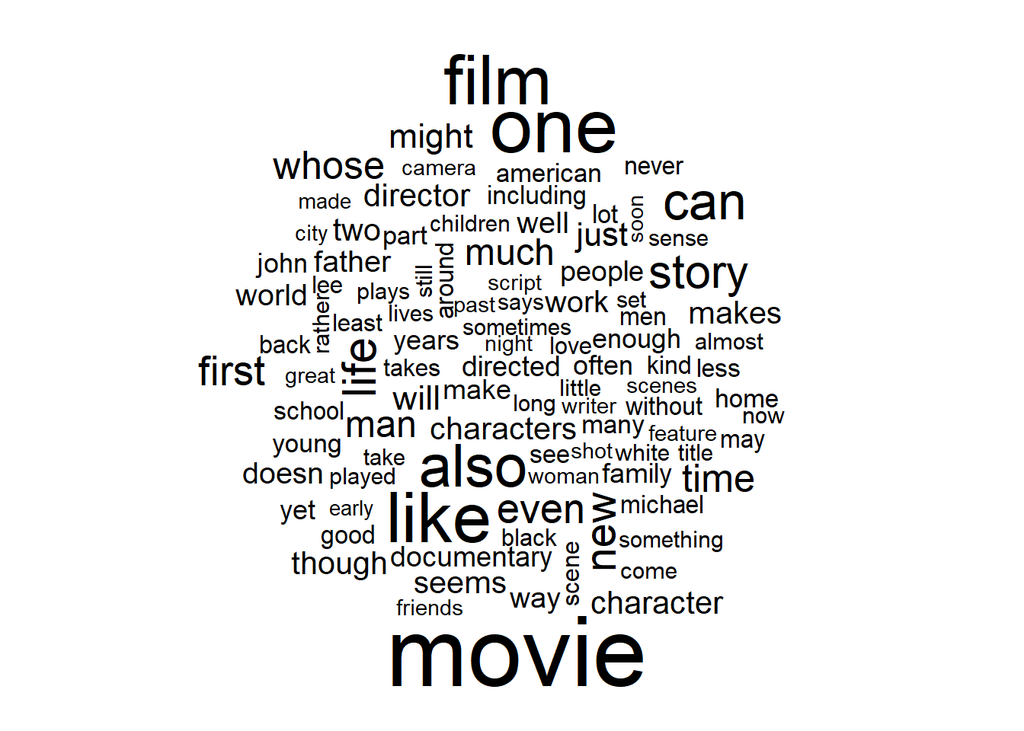

```r
words <- names(frequency)
wordcloud(words[1:100], frequency[1:100])
```

9.Conclusion

The biggest conclusion that I found is that NY Times movie reviwers don’t really use a lot of hyperbolic language in their reviews. Few negative or positive adjectives are used frequently in their reviews which implies that their reviews are far more subtle. Also, there are few mentions of box office, awards, sequels, etc.

Just looking at the frequency of the words, it’s difficult to find a common sentiment among these reviews.